# Clima do Brasil — Supervisionado vs Não-Supervisionado

## 3.6 Forecasting com Séries Temporais — Modelos Não-Supervisionados

Diferente da Parte I (que usou features externas + lag + ML), aqui cada modelo usa **apenas a história passada da série**. São modelos puramente univariados.

**Ver código**

```r
sp_ts    <- climate_ts |> filter(city == "São Paulo")
sp_train <- sp_ts |> filter(yearmonth <= yearmonth("2022 Dec"))
sp_test  <- sp_ts |> filter(yearmonth >= yearmonth("2023 Jan"))

cat(sprintf("Treino: %s → %s (%d meses)\n",
            min(sp_train$yearmonth), max(sp_train$yearmonth), nrow(sp_train)))
```

```
Treino: 1980 jan → 2022 dez (516 meses)
```

**Ver código**

```r
cat(sprintf("Teste:  %s → %s (%d meses)\n",
            min(sp_test$yearmonth),  max(sp_test$yearmonth),  nrow(sp_test)))
```

```
Teste:  2023 jan → 2024 dez (24 meses)
```

### 3.6.1 Temperatura — 5 modelos

**Ver código**

```r
models_temp <- sp_train |>
  model(
    Naive_Sazonal = SNAIVE(temp),
    Media_Hist    = MEAN(temp),
    ETS           = ETS(temp),
    ARIMA         = ARIMA(temp),
    STL_ETS       = decomposition_model(
      STL(temp ~ season(window = "periodic")), ETS(season_adjust)
    )
  )

fc_temp  <- models_temp |> forecast(new_data = sp_test)
acc_temp <- fc_temp |>
  accuracy(sp_test) |>
  select(.model, RMSE, MAE, MAPE, MASE) |>
  arrange(RMSE)

acc_temp |>
  mutate(across(where(is.numeric), ~round(., 3))) |>
  knitr::kable(caption = "Acurácia — Temperatura São Paulo (2023–2024)")
```

Acurácia — Temperatura São Paulo (2023–2024)

| .model | RMSE | MAE | MAPE | MASE |
| --- | --- | --- | --- | --- |
| ETS | 1.764 | 1.380 | 6.738 | NaN |
| STL_ETS | 1.785 | 1.409 | 6.891 | NaN |
| ARIMA | 2.037 | 1.540 | 7.435 | NaN |
| Media_Hist | 2.287 | 2.123 | 10.782 | NaN |
| Naive_Sazonal | 2.373 | 1.778 | 8.683 | NaN |

**Ver código**

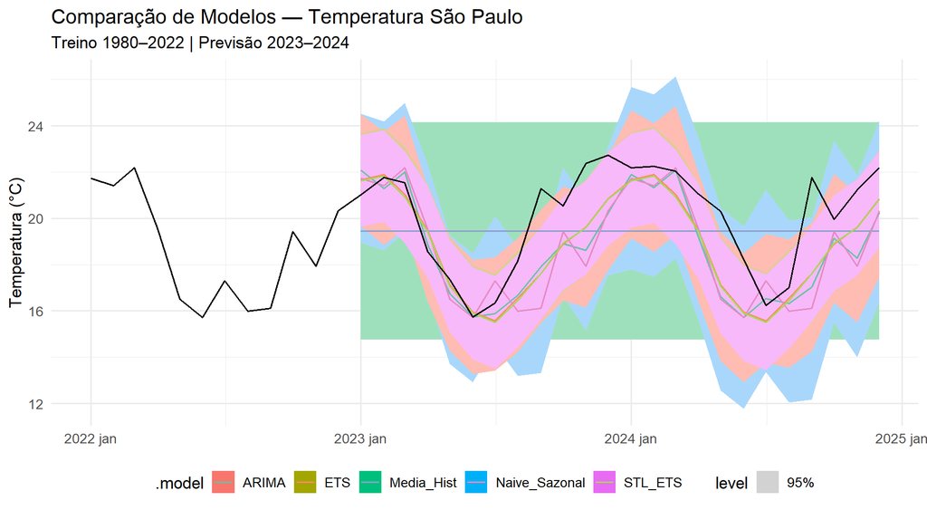

Figure 17: Previsões de temperatura com intervalo de 95% de confiança. STL+ETS e ARIMA tendem a superar o SNAIVE, que se limita a repetir o mesmo mês do ano anterior.

```r
fc_temp |>
  autoplot(sp_ts |> filter(yearmonth >= yearmonth("2022 Jan")), level = 95) +
  labs(title = "Comparação de Modelos — Temperatura São Paulo",
       subtitle = "Treino 1980–2022 | Previsão 2023–2024",
       x = NULL, y = "Temperatura (°C)") +
  scale_color_brewer(palette = "Set2") +
  theme_minimal(base_size = 13) +
  theme(legend.position = "bottom")
```

| Modelo | Estratégia | Uso ideal |
| --- | --- | --- |
| `SNAIVE` | Repete o mesmo mês do ano anterior | Baseline sazonal |
| `MEAN` | Média histórica constante | Baseline não-sazonal |
| `ETS` | Suavização exponencial adaptativa | Séries regulares |
| `ARIMA` | Autoregressivo com diferenciação | Autocorrelação complexa |
| `STL + ETS` | Decompõe sazonalidade, modela resíduo | Sazonalidade variável |

### 3.6.2 Precipitação — 5 modelos

Precipitação exige transformação: distribuição assimétrica, cauda longa, não pode ser negativa.

**Ver código**

```r
models_precip <- sp_train |>
  model(
    Naive_Sazonal = SNAIVE(precip),
    Media_Hist    = MEAN(precip),
    ETS_log       = ETS(log(precip + 1)),
    ARIMA         = ARIMA(precip ~ pdq() + PDQ()),
    STL_ETS       = decomposition_model(
      STL(log(precip + 1) ~ season(window = "periodic")), ETS(season_adjust)
    )
  )

fc_precip  <- models_precip |> forecast(new_data = sp_test)
acc_precip <- fc_precip |>
  accuracy(sp_test) |>
  select(.model, RMSE, MAE, MAPE, MASE) |>
  arrange(RMSE)

acc_precip |>
  mutate(across(where(is.numeric), ~round(., 3))) |>
  knitr::kable(caption = "Acurácia — Precipitação São Paulo (2023–2024)")
```

Acurácia — Precipitação São Paulo (2023–2024)

| .model | RMSE | MAE | MAPE | MASE |
| --- | --- | --- | --- | --- |
| ETS_log | 38.685 | 29.982 | 65.557 | NaN |
| STL_ETS | 40.645 | 31.642 | 68.516 | NaN |
| ARIMA | 56.594 | 43.195 | 89.898 | NaN |
| Naive_Sazonal | 68.625 | 51.625 | 113.664 | NaN |
| Media_Hist | 76.676 | 69.881 | 192.630 | NaN |

### 3.6.3 Heatmap RMSE — temperatura, múltiplas cidades

**Ver código**

```r
cities_sub <- c("Manaus","Recife","Brasília","São Paulo","Porto Alegre")

models_all <- climate_ts |>
  filter(city %in% cities_sub, yearmonth <= yearmonth("2022 Dec")) |>
  model(SNAIVE  = SNAIVE(temp),
        ETS     = ETS(temp),
        ARIMA   = ARIMA(temp),
        STL_ETS = decomposition_model(
          STL(temp ~ season(window = "periodic")), ETS(season_adjust)
        ))

acc_all <- models_all |>
  forecast(new_data = climate_ts |>
             filter(city %in% cities_sub, yearmonth >= yearmonth("2023 Jan"))) |>
  accuracy(climate_ts |> filter(city %in% cities_sub,
                                 yearmonth >= yearmonth("2023 Jan"))) |>
  select(city, .model, RMSE, MAE) |>
  arrange(city, RMSE)
```

**Ver código**

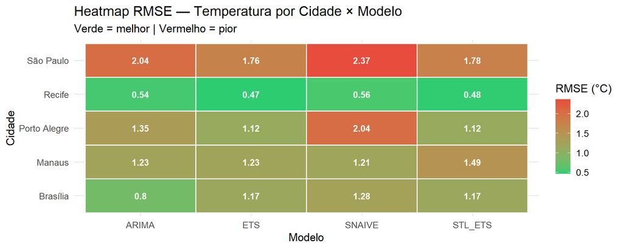

Figure 18: Heatmap de RMSE de temperatura por cidade × modelo. Verde = melhor performance. Um modelo com verde consistente em todas as cidades é mais robusto.

```r
acc_all |>
  ggplot(aes(.model, city, fill = RMSE)) +
  geom_tile(color = "white", linewidth = 0.6) +
  geom_text(aes(label = round(RMSE, 2)), color = "white", fontface = "bold", size = 3.5) +
  scale_fill_gradient(low = "#2ECC71", high = "#E74C3C") +
  labs(title = "Heatmap RMSE — Temperatura por Cidade × Modelo",
       subtitle = "Verde = melhor | Vermelho = pior",
       x = "Modelo", y = "Cidade", fill = "RMSE (°C)") +
  theme_minimal(base_size = 13)
```

# 4 Parte III — São Paulo Está Esquentando?

Esta seção investiga se há evidência de **aquecimento ao longo dos 45 anos** no registro ERA5 de São Paulo. Usamos os dados diários da Parte I (mais granulares) e os mensais da Parte II para análises complementares.

## 4.1 Tendência de Temperatura Anual

**Ver código**

```r
annual_sp <- weather_df |>
  mutate(year = year(date)) |>
  group_by(year) |>
  summarise(
    temp_mean   = mean(temp_mean, na.rm = TRUE),
    temp_max_m  = mean(temp_max,  na.rm = TRUE),
    temp_min_m  = mean(temp_min,  na.rm = TRUE),
    .groups     = "drop"
  )

# Regressão linear: temp ~ ano
lm_trend <- lm(temp_mean ~ year, data = annual_sp)
slope     <- coef(lm_trend)["year"]
pval      <- summary(lm_trend)$coefficients["year", "Pr(>|t|)"]

cat(sprintf("Taxa de aquecimento: %+.4f °C/ano → %+.3f °C/década\n",
            slope, slope * 10))
```

```
Taxa de aquecimento: +0.0079 °C/ano → +0.079 °C/década
```

**Ver código**

```r
cat(sprintf("p-valor (H0: slope = 0): %.4f %s\n",
            pval, ifelse(pval < 0.05, "→ significativo a 5%", "→ não-significativo")))
```

```
p-valor (H0: slope = 0): 0.1158 → não-significativo
```

**Ver código**

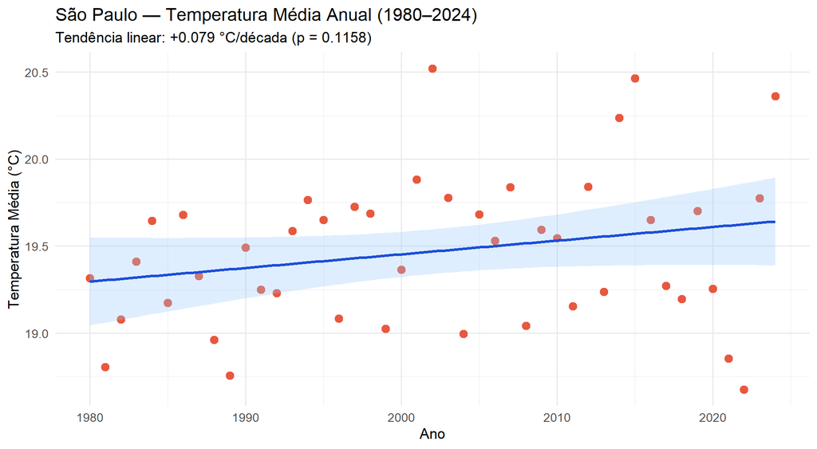

Figure 19: Temperatura média anual de São Paulo (1980–2024) com regressão linear e intervalo de confiança 95%. A inclinação da reta quantifica a taxa de aquecimento em °C/ano.

```r
ggplot(annual_sp, aes(year, temp_mean)) +
  geom_point(size = 3, color = "#E8583E") +
  geom_smooth(method = "lm", se = TRUE, color = "#1D4ED8",
              fill = "#93C5FD", alpha = 0.3, linewidth = 1.2) +
  labs(
    title    = "São Paulo — Temperatura Média Anual (1980–2024)",
    subtitle = sprintf("Tendência linear: %+.3f °C/década (p = %.4f)",
                       slope * 10, pval),
    x = "Ano", y = "Temperatura Média (°C)"
  ) +
  theme_minimal(base_size = 13)
```

## 4.2 Tendência Sazonal — Verão vs Inverno

Nem todas as estações aquecem igualmente. Verificamos se o aquecimento é mais forte no verão (DJF) ou no inverno (JJA).

**Ver código**

```r
seasonal_sp <- weather_df |>
  mutate(
    year = year(date),
    season = case_when(
      month(date) %in% c(12, 1, 2)  ~ "Verão (DJF)",
      month(date) %in% c(3, 4, 5)   ~ "Outono (MAM)",
      month(date) %in% c(6, 7, 8)   ~ "Inverno (JJA)",
      month(date) %in% c(9, 10, 11) ~ "Primavera (SON)"
    ),
    season = factor(season, levels = c("Verão (DJF)", "Outono (MAM)",
                                        "Inverno (JJA)", "Primavera (SON)"))
  ) |>
  group_by(year, season) |>
  summarise(temp_mean = mean(temp_mean, na.rm = TRUE), .groups = "drop")

# Calcular slope por estação
slopes_season <- seasonal_sp |>
  group_by(season) |>
  summarise(
    slope    = coef(lm(temp_mean ~ year))[2],
    pval     = summary(lm(temp_mean ~ year))$coefficients[2, 4],
    slope_10 = slope * 10,
    .groups  = "drop"
  )

slopes_season |>
  mutate(across(where(is.numeric), ~round(., 4))) |>
  knitr::kable(caption = "Taxa de aquecimento por estação (°C/ano e °C/década)")
```

Taxa de aquecimento por estação (°C/ano e °C/década)

| season | slope | pval | slope_10 |
| --- | --- | --- | --- |
| Verão (DJF) | 0.0040 | 0.5802 | 0.0404 |
| Outono (MAM) | -0.0075 | 0.3259 | -0.0746 |
| Inverno (JJA) | 0.0103 | 0.2040 | 0.1029 |
| Primavera (SON) | 0.0247 | 0.0078 | 0.2470 |

**Ver código**

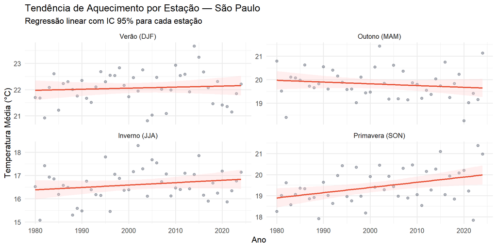

Figure 21: Tendência de temperatura por estação. Taxas de aquecimento distintas entre estações indicam mudanças na sazonalidade.

```r
ggplot(seasonal_sp, aes(year, temp_mean)) +
  geom_point(alpha = 0.5, size = 1.5, color = "#6B7280") +
  geom_smooth(method = "lm", se = TRUE, color = "#E8583E",
              fill = "#FECACA", alpha = 0.3, linewidth = 1) +
  facet_wrap(~season, scales = "free_y") +
  labs(
    title    = "Tendência de Aquecimento por Estação — São Paulo",
    subtitle = "Regressão linear com IC 95% para cada estação",
    x = "Ano", y = "Temperatura Média (°C)"
  ) +
  theme_minimal(base_size = 12)
```